# Identify X or Z Chromosomes from genotype data

Required:

- .vcf
- vcftools in path
- sex of individuals in your dataset (tab delimited)

Make list of chromosomes/scaffolds/contigs found in your .vcf

Take care not to have problematic characters such as ‘|’ in your scaffold names

The following is the code to run the vcftools –het analysis in a shell script or can be submitted to a job scheduler with the proper header.

This will result in an output directory containing observed and expected homozygosities, number of loci, and inbreeding coefficient (F) for each individual for each scaffold separately. Following the vcftools output, this script will concatenate all outputs and append scaffold information.

```bash
vcfile=yourgenotypes.vcf
chrfile=yourchr.txt
outdir=Homozygosities
homozygositiesfile=allhomozygosities.tsv


if [ ! -f "$outdir" ]; then
    mkdir $outdir
fi

cat $vcfile | grep -v "^#" | awk '{print $1}' | sort -u >$chrfile

for x in `cat $chrfile`
do
vcftools --vcf $vcfile --het --chr $x --out $x
done

for x in `cat $chrfile`
do
cat $outdir/$x.het | awk -F '\t' -v i=$x -v OFS='\t' '{print 'i', $0}' | grep -v "O(HOM)" >>$homozygositiesfile
done

sed -i '1iScaffold\tIndv\tO.hom)\tE.hom)\tN\tF' $homozygositiesfile
```

Below are R scripts to read in the single output file from above and a file you produce which contains the individual name (matching exactly with the individual name in the .vcf) and sex and appends sex information for all individuals to the augmented vcftools .het output. Additional columns are created to calculate the observed and expected heterozygosities, and observed and expected proportion heterozygosities. The last line selects only the relevant columns (Scaffold, Sex, and proportion of observed heterozygocities).

Required libraries:

- tidyverse
- plyr
- broom
- dplyr
- ggplot2

```r
sexes <- read_tsv("Sex_Chr/Test/indv_sex.tsv", col_names=T)
heterozygosities <- read_tsv("Sex_Chr/Test/allhomozygosities.tsv", col_names=T) %>%
  filter(N > 100) %>%
  inner_join(sexes) %>%
  mutate(O.het =  N - O.hom) %>%
  mutate(E.het = N - E.hom) %>%
  mutate(PE.het = E.het/N) %>%
  mutate(PO.het = O.het/N) %>%
  select(Scaffold, Sex, PO.het)
```

Below is a way to run a two-sample T test comparing the proportion of observed heterozygosities of females and males.

```r
data_summary <- function(data, varname, groupnames){
  require(plyr)
  summary_func <- function(x, col){
    c(mean = mean(x[[col]], na.rm=TRUE),
      sd = sd(x[[col]], na.rm=TRUE))
  }
  data_sum<-ddply(data, groupnames, .fun=summary_func,
                  varname)
  data_sum <- rename(data_sum, c("mean" = varname))
 return(data_sum)
}

df <- data_summary(heterozygosities, varname = "PO.het", groupnames = c("Scaffold", "Sex")) %>%
  pivot_wider(id_cols = Scaffold, names_from = Sex, values_from = c("PO.het", "sd")) %>%
  drop_na()

scaffKeepers <- df$Scaffold

est <- heterozygosities %>%
  filter(Scaffold %in% scaffKeepers) %>%
  group_by(Scaffold) %>%
  do(tidy(t.test(.$PO.het ~ .$Sex)))

df <- df %>%
  inner_join(est, by = "Scaffold") %>%
  mutate(Significant = ifelse(p.value < 0.001, "p-value < 0.001", ifelse(p.value >= 0.001, "p-value >= 0.001", "no")))
```

Create a scatter plot using the male proportion heterozygosity and the female heterozygosity with the standard deviations as lines on the x and y axes respectively.

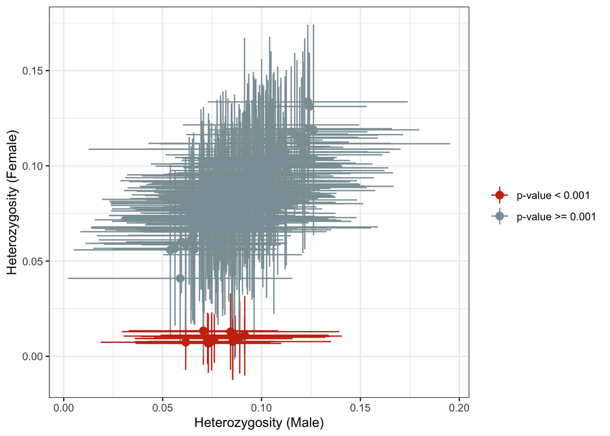

Average heterozygosity of males and females across all scaffolds containing biallelic SNPs. Scaffolds with a significant difference (p.value < 0.001) in average heterozygosity between males and females are in red.

```r
p <- ggplot(df, aes(x = PO.het_M, y = PO.het_F, color=Significant)) +
  geom_pointrange(aes(ymin = PO.het_F - sd_F, ymax = PO.het_F + sd_F)) +
  geom_errorbarh(aes(xmax = PO.het_M + sd_M, xmin = PO.het_M - sd_M, height = 0)) +
  labs(y="Heterozygosity (Female)", x = "Heterozygosity (Male)") +
  scale_color_manual(values = c("#C93312", "#899DA4")) +
  theme_bw()

p + theme(legend.title = element_blank())
```

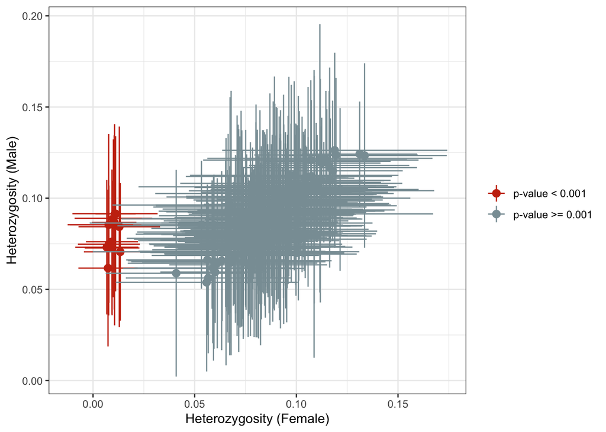

This is the same graph as above with the axes switched to be cute and put the male on the Y axis and the female on the X axis.

```r
p_switched <- ggplot(df, aes(x = PO.het_F, y = PO.het_M, color=Significant)) +
  geom_pointrange(aes(ymin = PO.het_M - sd_M, ymax = PO.het_M + sd_M)) +
  geom_errorbarh(aes(xmax = PO.het_F + sd_F, xmin = PO.het_F - sd_F, height = 0)) +
  labs(y="Heterozygosity (Male)", x = "Heterozygosity (Female)") +
  scale_color_manual(values = c("#C93312", "#899DA4")) +
  theme_bw()

p_switched + theme(legend.title = element_blank())
```

This table shows the X or Z linked scaffolds based on these analyses.

```r
XZ_linked <- df %>%
  filter(p.value <= 0.001) %>%
  filter(PO.het_F < 0.05) %>%
  select(Scaffold, PO.het_F, PO.het_M, sd_F, sd_M, p.value, method)

XZ_linked
```

| Scaffold | PO.het_F | PO.het_M | sd_F | sd_M | p.value | method |
| --- | --- | --- | --- | --- | --- | --- |
| NW_020662826.1 | 0.007803450 | 0.07477821 | 0.015249914 | 0.03215003 | 4.370624e-23 | Welch Two Sample t-test |
| NW_020662831.1 | 0.007714524 | 0.08544913 | 0.020197067 | 0.04970527 | 1.269894e-17 | Welch Two Sample t-test |
| NW_020662833.1 | 0.010616127 | 0.08542073 | 0.022008104 | 0.05513324 | 8.233688e-15 | Welch Two Sample t-test |
| NW_020662860.1 | 0.013389002 | 0.07057006 | 0.017891673 | 0.03773465 | 8.386682e-17 | Welch Two Sample t-test |
| NW_020662867.1 | 0.007375490 | 0.06167107 | 0.014581980 | 0.04299106 | 1.128666e-13 | Welch Two Sample t-test |
| NW_020662870.1 | 0.006772833 | 0.07309043 | 0.015497773 | 0.03684906 | 1.036356e-20 | Welch Two Sample t-test |
| NW_020662873.1 | 0.012924537 | 0.08433378 | 0.020062482 | 0.05494598 | 3.981033e-14 | Welch Two Sample t-test |
| NW_020662887.1 | 0.009377872 | 0.07271302 | 0.013461332 | 0.03686508 | 1.179403e-19 | Welch Two Sample t-test |
| NW_020662899.1 | 0.010810387 | 0.09149748 | 0.020952605 | 0.03555602 | 2.034030e-26 | Welch Two Sample t-test |
| NW_020662910.1 | 0.011086982 | 0.09145821 | 0.009869154 | 0.04255532 | 2.009715e-21 | Welch Two Sample t-test |

[output cut: 3 more lines]